# Experiment 4

Stas Sajin

October 10, 2015

# Synopsis

The aim of this document is to provide a summary of all the analyses used in writing up the results for Experiment 4 in the dissertation document.The analyses are brokwn down into several parts:

1. Data Cleaning and Pre-processing
2. Exploratory Analyses
3. Growth Curve Analysis
4. Graphs

#### *Libraries*

Load the required libraries

```r
library(ggplot2)
library(lme4)
library(lmerTest)
library(dplyr)
library(parallel)
library(doParallel)
library(tidyr)
library(gridExtra)
library(caret)
library(multcomp)
```

#### *Data Loading*

Not all colums in the results file are required. Only the following colums will be loaded in R, so as to preserve memory space. The colums are: RECORDING_SESSION_LABEL, IA_FIRST_RUN_START_TIME, IA_FIRST_RUN_START_TIME, IA_FIRST_RUN_END_TIME, IA_SECOND_RUN_START_TIME, IA_SECOND_RUN_END_TIME, IA_THIRD_RUN_START_TIME, IA_THIRD_RUN_END_TIME, IA_LABEL, RESPONSE_ACC, IA_DWELL_TIME, TRIAL_INDEX, RESPONSE_RT,trialtype,target,Bilingual, list, colorcompetitor, colorofblock

```r
EyeData <- read.csv("Exp4DriftCorrectedVersion2.csv", na.strings = c("."))[,c('RECORDING_SESSION_LABEL', 'IA_FIRST_RUN_START_TIME', 'IA_FIRST_RUN_START_TIME', 'IA_FIRST_RUN_END_TIME', 'IA_SECOND_RUN_START_TIME', 'IA_SECOND_RUN_END_TIME', 'IA_THIRD_RUN_START_TIME', 'IA_THIRD_RUN_END_TIME', 'IA_LABEL', 'RESPONSE_ACC', 'IA_DWELL_TIME', 'TRIAL_INDEX', 'target', 'RESPONSE_RT', 'trialtype','Bilingual','list','colorcompetitor', 'colorofblock')]
#change all the NAs to zeros
EyeData[is.na(EyeData)] <- 0
#check the dimentions of the dataset
dim(EyeData)
```

```
## [1] 11400    19
```

```r
#rename the RECORDING_SESSION_LABEL into Subject
colnames(EyeData)[1] <- "Subject"
#examine colum names
names(EyeData)
```

```
##  [1] "Subject"                   "IA_FIRST_RUN_START_TIME"
##  [3] "IA_FIRST_RUN_START_TIME.1" "IA_FIRST_RUN_END_TIME"
##  [5] "IA_SECOND_RUN_START_TIME"  "IA_SECOND_RUN_END_TIME"
##  [7] "IA_THIRD_RUN_START_TIME"   "IA_THIRD_RUN_END_TIME"
##  [9] "IA_LABEL"                  "RESPONSE_ACC"
## [11] "IA_DWELL_TIME"             "TRIAL_INDEX"
## [13] "target"                    "RESPONSE_RT"
## [15] "trialtype"                 "Bilingual"
## [17] "list"                      "colorcompetitor"
## [19] "colorofblock"
```

Examine the structure of the dataframe

```r
str(EyeData)
```

```
## 'data.frame':    11400 obs. of  19 variables:
##  $ Subject                  : Factor w/ 25 levels "e4l1s1","e4l1s13",..: 1 1 1 1 1 1 1 1 1 1 ...
##  $ IA_FIRST_RUN_START_TIME  : num  4088 3296 3852 3008 2732 ...
##  $ IA_FIRST_RUN_START_TIME.1: num  4088 3296 3852 3008 2732 ...
##  $ IA_FIRST_RUN_END_TIME    : num  4594 3598 4026 3242 3306 ...
##  $ IA_SECOND_RUN_START_TIME : num  5424 0 0 0 3944 ...
##  $ IA_SECOND_RUN_END_TIME   : num  5610 0 0 0 4254 ...
##  $ IA_THIRD_RUN_START_TIME  : num  0 0 0 0 0 0 0 0 0 0 ...
##  $ IA_THIRD_RUN_END_TIME    : num  0 0 0 0 0 0 0 0 0 0 ...
##  $ IA_LABEL                 : Factor w/ 4 levels "COMPET_IA ","TARGET_IA ",..: 2 1 3 4 2 1 3 4 2 1 ...
##  $ RESPONSE_ACC             : int  1 1 1 1 0 0 0 0 0 0 ...
##  $ IA_DWELL_TIME            : int  680 292 176 236 888 0 0 0 592 0 ...
##  $ TRIAL_INDEX              : int  1 1 1 1 2 2 2 2 3 3 ...
##  $ target                   : Factor w/ 114 levels "agree","alarm",..: 31 31 31 31 100 100 100 100 89 89 ...
##  $ RESPONSE_RT              : num  3093 3093 3093 3093 1745 ...
##  $ trialtype                : Factor w/ 4 levels "Experimental",..: 4 4 4 4 4 4 4 4 4 4 ...
##  $ Bilingual                : Factor w/ 2 levels "no","yes": 1 1 1 1 1 1 1 1 1 1 ...
##  $ list                     : int  1 1 1 1 1 1 1 1 1 1 ...
##  $ colorcompetitor          : Factor w/ 4 levels "Congruous","IncongruousComp",..: 4 4 4 4 4 4 4 4 4 4 ...
##  $ colorofblock             : Factor w/ 4 levels "Blue","Green",..: 4 4 4 4 1 1 1 1 3 3 ...
```

Everything looks fine.

## *Data Cleaning and PreProcessing*

Remove practice trials

```r
EyeData <- subset(EyeData, EyeData$trialtype!="Practice")
```

Check subject accuracy and RT for the selection of the word responses

```r
SubjectAccuracy<- EyeData %>% group_by(Subject) %>%
    summarise(MeanAccuracy=mean(RESPONSE_ACC)) %>% arrange(MeanAccuracy)
SubjectAccuracy
```

```
## Source: local data frame [25 x 2]
##
##    Subject MeanAccuracy
## 1   e4l4s4    0.9444444
## 2   e4l1s9    0.9722222
## 3   e4l3s7    0.9722222
## 4  e4l4s16    0.9722222
## 5  e4l1s13    0.9814815
## 6  e4l1s21    0.9814815
## 7  e4l2s14    0.9814815
## 8  e4l2s18    0.9814815
## 9  e4l4s12    0.9814815
## 10 e4l1s17    0.9907407
## ..     ...          ...
```

```r
mean(SubjectAccuracy$MeanAccuracy)
```

```
## [1] 0.9885185
```

```r
SubjectRT<- EyeData %>% group_by(Subject) %>%
    summarise(MeanRT=mean(RESPONSE_RT)) %>% arrange(MeanRT)
SubjectRT
```

```
## Source: local data frame [25 x 2]
##
##    Subject   MeanRT
## 1   e4l4s8 1172.164
## 2  e4l2s18 1270.554
## 3  e4l4s20 1338.015
## 4  e4l4s24 1379.862
## 5  e4l3s23 1422.287
## 6   e4l4s4 1507.359
## 7  e4l1s25 1516.516
## 8   e4l2s2 1538.731
## 9   e4l3s7 1553.997
## 10 e4l1s21 1567.897
## ..     ...      ...
```

```r
mean(SubjectRT$MeanRT)
```

```
## [1] 1716.362
```

Remove trials with incorrect accuracy

```r
CorrectEyeData<-EyeData %>% filter(RESPONSE_ACC==1)
```

Set up the start time and the end time dummy-coding of each run in the interest area. This creates colums where if a fixation exists during a run, then the run gets 1 (exists) or if there is no fixation in the IA during a run, then the coding is 0 (not exist)

```r
CorrectEyeData$Fststart <- ifelse(as.numeric(as.character(CorrectEyeData$IA_FIRST_RUN_START_TIME)) > 0, as.numeric(as.character(CorrectEyeData$IA_FIRST_RUN_START_TIME)), 0)
CorrectEyeData$Fstend <- ifelse(as.numeric(as.character(CorrectEyeData$IA_FIRST_RUN_START_TIME)) > 0, as.numeric(as.character(CorrectEyeData$IA_FIRST_RUN_END_TIME)), 0)
CorrectEyeData$Secstart <- ifelse(as.numeric(as.character(CorrectEyeData$IA_SECOND_RUN_START_TIME)) > 0, as.numeric(as.character(CorrectEyeData$IA_SECOND_RUN_START_TIME)), 0)
CorrectEyeData$Secend <- ifelse(as.numeric(as.character(CorrectEyeData$IA_SECOND_RUN_START_TIME)) > 0, as.numeric(as.character(CorrectEyeData$IA_SECOND_RUN_END_TIME)), 0)
CorrectEyeData$Thirdstart <- ifelse(as.numeric(as.character(CorrectEyeData$IA_THIRD_RUN_START_TIME)) > 0, as.numeric(as.character(CorrectEyeData$IA_THIRD_RUN_START_TIME)), 0)
CorrectEyeData$Thirdend <- ifelse(as.numeric(as.character(CorrectEyeData$IA_THIRD_RUN_START_TIME)) > 0, as.numeric(as.character(CorrectEyeData$IA_THIRD_RUN_END_TIME)), 0)
```

Generate time bins from time 0 to time 6000 in 25 ms bins and assign them to the dataset

```r
time <- seq(0, 6000, by=25)
tmatrix <- matrix(nrow=nrow(CorrectEyeData), ncol=length(time))
dim(tmatrix)
```

```
## [1] 10676   241
```

Generate time vectors for each row and column for first, second, and third pass viewings so that viewing periods receive a viewing probability value of 1

```r
registerDoParallel(3)
for(i in 1:nrow(tmatrix)) {
for(j in 1:length(time)) {

tmatrix[i,j] <-  ifelse(CorrectEyeData$Fststart[i] < time[j] &
                CorrectEyeData$Fstend[i] > time[j] |CorrectEyeData$Secstart[i] <
                time[j] & CorrectEyeData$Secend[i] > time[j] | CorrectEyeData$Thirdstart[i]
                < time[j] & CorrectEyeData$Thirdend[i]>time[j], 1,0)
}
}
```

Combine the CleanEyeData with the time matrix

```r
CleanData <- cbind(CorrectEyeData, data.frame(tmatrix))
```

Assign time values to time bin columns

```r
colnames(CleanData)[26:266] <- seq(0, 6000, by=25)
```

Subset the dataset with only the necessary colums and remove anything in the memory that might be a memory hog

```r
CleanData <- CleanData[, -c(2:8,10,11,20:25)]
```

Put the data in long-format and then calculate the proportion for each time bin for each subject

```r
CleanData<- CleanData %>% gather(time,value,11:251)
#find proportion for each interest area for each subject
CleanDataProb<-CleanData %>% group_by(Subject,colorcompetitor,IA_LABEL,trialtype,time) %>%
    summarise(Prob=mean(value))
CleanDataProb$time<-as.numeric(as.character(CleanDataProb$time))
```

## **Exploratory Graphs**

The aim of this section is to explore pattern in the data without commiting to any formal modeling. Several questions will be addressed thoguh exploratory graphs

1. In trials in which the color of the target is congruent with the color of the block, can we observe competition effects? Are competition effects enhanced when the competitor is in the same color as the target?
2. Is having bilinguals in this experiment an issue? There were 4 subjects who reported being bilingual, though they spoke English at home.

```r
#subset the required dataset by averaging over subjects; find the usual
OnlySubjects<-CleanData %>% group_by(IA_LABEL,trialtype,time,colorcompetitor) %>%
    summarise(n=n(),Prob=mean(value),sd=sd(value)) %>%
    mutate(se=sd/sqrt(n), LCI=Prob+qnorm(0.025)*se, UCI=Prob+qnorm(0.975)*se)
OnlySubjects$time<-as.numeric(as.character(OnlySubjects$time))

levels(OnlySubjects$IA_LABEL) <- list(Target="TARGET_IA ", Competitor="COMPET_IA ", Distractor1="UNREL1_IA ", Distractor2="UNREL2_IA ")


levels(OnlySubjects$colorcompetitor) <- list(Congruous="Congruous", `Incongruous Competitor`="IncongruousComp", `Incongruous Distr.`="IncongruousDistr")

colnames(OnlySubjects)[1]<-"Interest Area"
```

```r
#plot for time 0 to time 6000
cbPalette <- c("#999999", "#E69F00", "#56B4E9", "#009E73", "#F0E442", "#0072B2", "#D55E00", "#CC79A7")
g1<-ggplot(OnlySubjects, aes(x=time, y=Prob, shape=`Interest Area`, color=`Interest Area`)) +
    geom_point(size=3) +
    geom_errorbar(aes(ymin=LCI, ymax=UCI)) + facet_grid(colorcompetitor~trialtype)+
    scale_x_continuous(limits = c(0, 6000))+
    geom_vline(xintercept = 2000+675)+
    geom_vline(xintercept = 5200)+theme_bw()+
    scale_fill_manual(values=cbPalette)+scale_colour_manual(values=cbPalette)+
    scale_x_continuous(name="time from onset of fixation cross(ms)")+
    scale_y_continuous(name="Fixation Proportion")+
    theme(legend.text = element_text(size = 12))+
    theme(legend.title = element_text(size=12, face="bold"))+
    theme(axis.title.x = element_text(face="bold", size=15), axis.text.x  = element_text(size=10))+
    theme(axis.title.y = element_text(face="bold", size=15), axis.text.y  = element_text(size=10))+
    theme(strip.text.x = element_text(size=12, face="bold"))+
    theme(strip.text.y = element_text(size=12, face="bold"))+
    theme(plot.title = element_text(lineheight=.8, face="bold", size=14))

#plot from time 1000(fixation cross)+1000(word display with no sound)+682(click on duration).
g2<-ggplot(OnlySubjects, aes(x=time, y=Prob, shape=`Interest Area`, color=`Interest Area`)) +
    geom_point(size=3) +
    geom_errorbar(aes(ymin=LCI, ymax=UCI)) + facet_grid(colorcompetitor~trialtype)+
    theme_bw()+
    scale_fill_manual(values=cbPalette)+scale_colour_manual(values=cbPalette)+
    scale_x_continuous(name="time from onset of fixation cross(ms)")+
    scale_y_continuous(name="Fixation Proportion")+
    theme(legend.text = element_text(size = 12))+
    theme(legend.title = element_text(size=12, face="bold"))+
    theme(axis.title.x = element_text(face="bold", size=15), axis.text.x  = element_text(size=10))+
    theme(axis.title.y = element_text(face="bold", size=15), axis.text.y  = element_text(size=10))+
    theme(strip.text.x = element_text(size=12, face="bold"))+
    theme(strip.text.y = element_text(size=12, face="bold"))+
    theme(plot.title = element_text(lineheight=.8, face="bold", size=14))+
    scale_x_continuous(limits = c(2000+675, 5200))

png(filename="plot1Experiment4.png",width=900,height=524)
g1
dev.off()
```

```r
png(filename="plot2Experiment4.png",width=900,height=524)
g2
dev.off()
```

```r
colnames(OnlySubjects)[1]<-"InterestArea"
colnames(OnlySubjects)[4]<-"Congruence"
cbPalette <- c("#999999", "#E69F00", "#56B4E9", "#009E73", "#F0E442", "#0072B2", "#D55E00", "#CC79A7")
g3<-ggplot(OnlySubjects, aes(x=time, y=Prob, shape=Congruence, color=Congruence)) +
    geom_point(size=3) +
    geom_errorbar(aes(ymin=LCI, ymax=UCI)) + facet_grid(InterestArea~trialtype)+
    theme_bw()+
    scale_fill_manual(values=cbPalette, name="Congruence Condition")+
    scale_colour_manual(values=cbPalette)+
    scale_x_continuous(name="time from onset of fixation cross(ms)")+
    scale_y_continuous(name="Fixation Proportion")+
    theme(legend.text = element_text(size = 12))+
    theme(legend.title = element_text(size=12, face="bold"))+
    theme(axis.title.x = element_text(face="bold", size=15), axis.text.x  = element_text(size=10))+
    theme(axis.title.y = element_text(face="bold", size=15), axis.text.y  = element_text(size=10))+
    theme(strip.text.x = element_text(size=12, face="bold"))+
    theme(strip.text.y = element_text(size=12, face="bold"))+
    theme(plot.title = element_text(lineheight=.8, face="bold", size=14))+
    scale_x_continuous(limits = c(2000+675, 5200))

png(filename="plot3Experiment4.png",width=900,height=524)
g3
dev.off()
```

The graph below will examine the data from four bilinguals

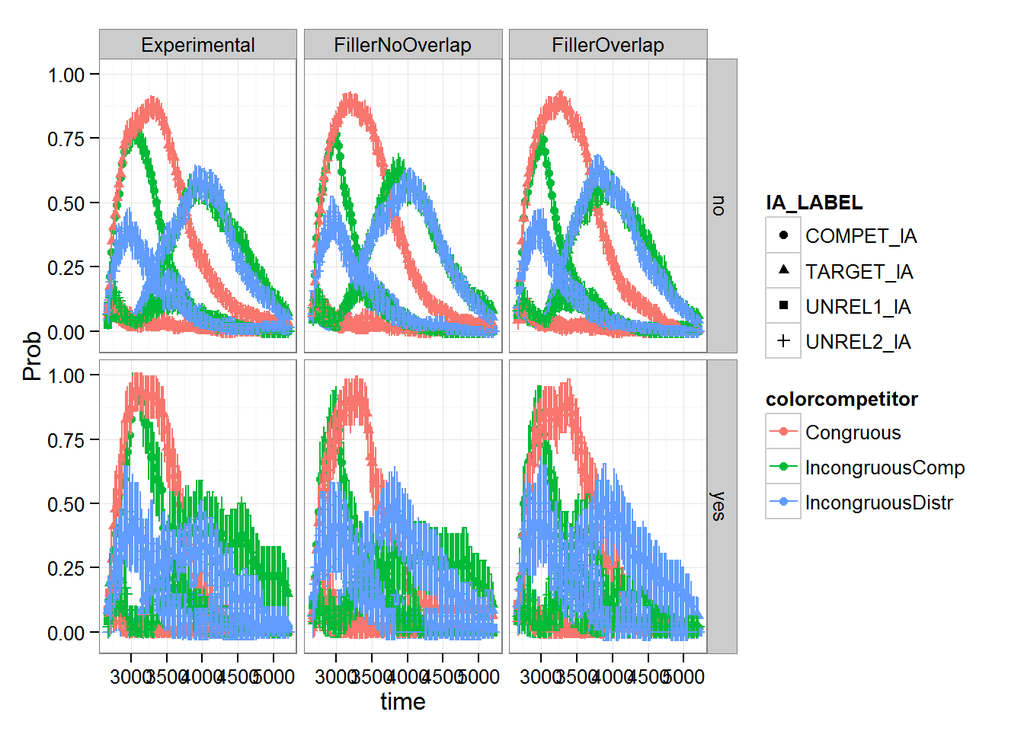

```r
OnlySubjects<-CleanData %>% group_by(IA_LABEL,trialtype,time,colorcompetitor,Bilingual) %>%
    summarise(n=n(),Prob=mean(value),sd=sd(value)) %>%
    mutate(se=sd/sqrt(n), LCI=Prob+qnorm(0.025)*se, UCI=Prob+qnorm(0.975)*se)
OnlySubjects$time<-as.numeric(as.character(OnlySubjects$time))


ggplot(OnlySubjects, aes(x=time, y=Prob, shape=IA_LABEL, color=colorcompetitor)) +
    geom_point() +
    geom_errorbar(aes(ymin=LCI, ymax=UCI)) + facet_grid(Bilingual~trialtype)+
    scale_x_continuous(limits = c(2000+675, 5200))+
    theme_bw()
```

There doesn’t seem to be any substantial differences between bilinguals and natives. The data patterns look the same, though the bilingual data has substantially more variability in it because there are only 4 subjects, and their responses are distributed acorss 9 conditions (3-trialtype x 3 congruency)

## **Growth Curve Analyses**

The following analyses will examine 1. the proportion fixations in Experimental trials between the Target (Congruent) vs Target (Incongruent Competitor) vs Target (Incongruent Distractor) 2. the proportion fixations in Experimental trials between the Competitor (Congruent) vs Competitor (Incongruent Competitor) vs Competitor (Incongruent Distractor)

First, the required subset for the `1st` analysis is created

```r
model<-CleanDataProb %>%
    filter(trialtype=="Experimental", IA_LABEL=="TARGET_IA ", colorcompetitor!="Practice", time>=2000+675 & time <=5200)
model$IA_LABEL<-as.factor(as.character(model$IA_LABEL))
model$colorcompetitor<-as.factor(as.character(model$colorcompetitor))

#Generate time polynomials up to quadratic poly.
t25 <- data.frame(poly(unique(model$time),4))
t25$time <- seq(2000+675, 5200, by=25)

#add polynomials to data frame
model <- merge(model , t25, by="time")
head(model)
```

```
##   time Subject  colorcompetitor   IA_LABEL    trialtype       Prob
## 1 2675  e4l1s1        Congruous TARGET_IA  Experimental 0.08333333
## 2 2675 e4l2s14  IncongruousComp TARGET_IA  Experimental 0.00000000
## 3 2675 e4l3s23 IncongruousDistr TARGET_IA  Experimental 0.00000000
## 4 2675  e4l3s7        Congruous TARGET_IA  Experimental 0.09090909
## 5 2675 e4l1s13  IncongruousComp TARGET_IA  Experimental 0.00000000
## 6 2675  e4l3s7 IncongruousDistr TARGET_IA  Experimental 0.00000000
##           X1        X2         X3        X4
## 1 -0.1698254 0.2149861 -0.2470002 0.2692958
## 2 -0.1698254 0.2149861 -0.2470002 0.2692958
## 3 -0.1698254 0.2149861 -0.2470002 0.2692958
## 4 -0.1698254 0.2149861 -0.2470002 0.2692958
## 5 -0.1698254 0.2149861 -0.2470002 0.2692958
## 6 -0.1698254 0.2149861 -0.2470002 0.2692958
```

```r
str(model)
```

```
## 'data.frame':    7650 obs. of  10 variables:
##  $ time           : num  2675 2675 2675 2675 2675 ...
##  $ Subject        : Factor w/ 25 levels "e4l1s1","e4l1s13",..: 1 9 17 19 2 19 3 11 3 12 ...
##  $ colorcompetitor: Factor w/ 3 levels "Congruous","IncongruousComp",..: 1 2 3 1 2 3 1 2 3 3 ...
##  $ IA_LABEL       : Factor w/ 1 level "TARGET_IA ": 1 1 1 1 1 1 1 1 1 1 ...
##  $ trialtype      : Factor w/ 4 levels "Experimental",..: 1 1 1 1 1 1 1 1 1 1 ...
##  $ Prob           : num  0.0833 0 0 0.0909 0 ...
##  $ X1             : num  -0.17 -0.17 -0.17 -0.17 -0.17 ...
##  $ X2             : num  0.215 0.215 0.215 0.215 0.215 ...
##  $ X3             : num  -0.247 -0.247 -0.247 -0.247 -0.247 ...
##  $ X4             : num  0.269 0.269 0.269 0.269 0.269 ...
```

The following models are run, with increasing complexity:

Model 1: A base model with no polynomials and only with the fixed effect IA_LABEL and random effect of subject intercept and nested condition with subject intercept.

Model 2: Base model with the addition of the linear polynomial for the fixed and random effect structure

Model 3. Model above+the addition of the quadratic polynomial in the fixed effect and random effect structure

Model 4. Model 3+addition of the third poly in the fixed and random effect structure. Model fails to converge

Model 5. Model 4+addition of the third poly in the fixed and in the random structure(subject only); converged

Model 6. Model 4+addition of the third poly in the fixed and random; fails to converge structure(subject:condition only)

```r
#relevel the colorcompetitor variable, so that multiple comparisons of the factor variable are compared as follows
# target (congruent) vs target (incongruent comp)
# target (incongruent dist) vs target (incongruent distr)
model$colorcompetitorReleveled <- relevel(model$colorcompetitor, "IncongruousComp")

registerDoParallel(3)
#base model; Model1
Model1<-lmer(Prob ~ colorcompetitorReleveled +
                 (1| Subject) +
                 (1| Subject:colorcompetitorReleveled),
               data=model, REML=T)
summary(Model1)
```

```
## Linear mixed model fit by REML t-tests use Satterthwaite approximations
##   to degrees of freedom [lmerMod]
## Formula:
## Prob ~ colorcompetitorReleveled + (1 | Subject) + (1 | Subject:colorcompetitorReleveled)
##    Data: model
##
## REML criterion at convergence: 2346.4
##
## Scaled residuals:
##     Min      1Q  Median      3Q     Max
## -1.9252 -0.8180 -0.2068  0.7064  2.6924
##
## Random effects:
##  Groups                           Name        Variance Std.Dev.
##  Subject:colorcompetitorReleveled (Intercept) 0.002895 0.05380
##  Subject                          (Intercept) 0.005762 0.07591
##  Residual                                     0.077743 0.27882
## Number of obs: 7650, groups:
## Subject:colorcompetitorReleveled, 75; Subject, 25
##
## Fixed effects:
##                                          Estimate Std. Error       df
## (Intercept)                               0.27056    0.01941 41.18000
## colorcompetitorReleveledCongruous         0.10222    0.01710 48.00000
## colorcompetitorReleveledIncongruousDistr -0.01415    0.01710 48.00000
##                                          t value Pr(>|t|)
## (Intercept)                               13.939  < 2e-16 ***
## colorcompetitorReleveledCongruous          5.976 2.73e-07 ***
## colorcompetitorReleveledIncongruousDistr  -0.827    0.412
## ---
## Signif. codes:  0 '***' 0.001 '**' 0.01 '*' 0.05 '.' 0.1 ' ' 1
##
## Correlation of Fixed Effects:
##             (Intr) clrcRC
## clrcmpttrRC -0.441
## clrcmpttRID -0.441  0.500
```

```r
#linear; model 2
Model2<-lmer(Prob ~ colorcompetitorReleveled*X1 +
                 (1+X1| Subject) +
                 (1+X1| Subject:colorcompetitorReleveled),
               data=model, REML=T)
summary(Model2)
```

```
## Linear mixed model fit by REML t-tests use Satterthwaite approximations
##   to degrees of freedom [lmerMod]
## Formula: Prob ~ colorcompetitorReleveled * X1 + (1 + X1 | Subject) + (1 +
##     X1 | Subject:colorcompetitorReleveled)
##    Data: model
##
## REML criterion at convergence: -1132
##
## Scaled residuals:
##     Min      1Q  Median      3Q     Max
## -4.2953 -0.6745 -0.1487  0.6680  3.2743
##
## Random effects:
##  Groups                           Name        Variance Std.Dev. Corr
##  Subject:colorcompetitorReleveled (Intercept) 0.003172 0.05632
##                                   X1          0.305172 0.55242  0.02
##  Subject                          (Intercept) 0.005777 0.07600
##                                   X1          0.273153 0.52264  1.00
##  Residual                                     0.048080 0.21927
## Number of obs: 7650, groups:
## Subject:colorcompetitorReleveled, 75; Subject, 25
##
## Fixed effects:
##                                             Estimate Std. Error       df
## (Intercept)                                  0.27056    0.01941 41.10000
## colorcompetitorReleveledCongruous            0.10222    0.01707 49.99000
## colorcompetitorReleveledIncongruousDistr    -0.01415    0.01707 49.99000
## X1                                           0.46821    0.15829 52.18000
## colorcompetitorReleveledCongruous:X1        -3.13078    0.16811 56.79000
## colorcompetitorReleveledIncongruousDistr:X1 -0.32937    0.16811 56.79000
##                                             t value Pr(>|t|)
## (Intercept)                                  13.939  < 2e-16 ***
## colorcompetitorReleveledCongruous             5.988 2.29e-07 ***
## colorcompetitorReleveledIncongruousDistr     -0.829  0.41101
## X1                                            2.958  0.00465 **
## colorcompetitorReleveledCongruous:X1        -18.624  < 2e-16 ***
## colorcompetitorReleveledIncongruousDistr:X1  -1.959  0.05499 .
## ---
## Signif. codes:  0 '***' 0.001 '**' 0.01 '*' 0.05 '.' 0.1 ' ' 1
##
## Correlation of Fixed Effects:
##             (Intr) clrcRC clrRID X1     cRC:X1
## clrcmpttrRC -0.440
## clrcmpttRID -0.440  0.500
## X1           0.524 -0.007 -0.007
## clrcmpRC:X1 -0.006  0.014  0.007 -0.531
## clrcmRID:X1 -0.006  0.007  0.014 -0.531  0.500
```

```r
#linea+quadratic; model 3
Model3<-lmer(Prob ~ colorcompetitorReleveled*(X1+X2) +
                 (1+X1+X2| Subject) +
                 (1+X1+X2| Subject:colorcompetitorReleveled),
               data=model, REML=T)
summary(Model3)
```

```
## Linear mixed model fit by REML t-tests use Satterthwaite approximations
##   to degrees of freedom [lmerMod]
## Formula: Prob ~ colorcompetitorReleveled * (X1 + X2) + (1 + X1 + X2 |
##     Subject) + (1 + X1 + X2 | Subject:colorcompetitorReleveled)
##    Data: model
##
## REML criterion at convergence: -5255.1
##
## Scaled residuals:
##     Min      1Q  Median      3Q     Max
## -5.8727 -0.6202 -0.0531  0.6267  3.1909
##
## Random effects:
##  Groups                           Name        Variance Std.Dev. Corr
##  Subject:colorcompetitorReleveled (Intercept) 0.003349 0.05787
##                                   X1          0.325406 0.57044   0.01
##                                   X2          0.441526 0.66447  -0.50
##  Subject                          (Intercept) 0.005805 0.07619
##                                   X1          0.273929 0.52338   1.00
##                                   X2          0.176517 0.42014  -1.00
##  Residual                                     0.027072 0.16454
##
##
##
##   0.42
##
##
##  -1.00
##
## Number of obs: 7650, groups:
## Subject:colorcompetitorReleveled, 75; Subject, 25
##
## Fixed effects:
##                                             Estimate Std. Error       df
## (Intercept)                                  0.27056    0.01941 40.93000
## colorcompetitorReleveledCongruous            0.10222    0.01701 51.21000
## colorcompetitorReleveledIncongruousDistr    -0.01415    0.01701 51.21000
## X1                                           0.46821    0.15829 52.08000
## X2                                          -1.42547    0.16064 62.65000
## colorcompetitorReleveledCongruous:X1        -3.13078    0.16792 57.81000
```

[output cut: 11 more lines]

```
## colorcompetitorReleveledCongruous:X2          5.185 2.30e-06 ***
## colorcompetitorReleveledIncongruousDistr:X2  -0.498  0.62041
## ---
## Signif. codes:  0 '***' 0.001 '**' 0.01 '*' 0.05 '.' 0.1 ' ' 1
##
## Correlation of Fixed Effects:
##             (Intr) clrcRC clrRID X1     X2     cRC:X1 cRID:X1 cRC:X2
## clrcmpttrRC -0.438
## clrcmpttRID -0.438  0.500
## X1           0.524 -0.005 -0.005
## X2          -0.656  0.281  0.281 -0.093
## clrcmpRC:X1 -0.004  0.010  0.005 -0.530 -0.239
## clrcmRID:X1 -0.004  0.005  0.010 -0.530 -0.239  0.500
## clrcmpRC:X2  0.204 -0.466 -0.233 -0.210 -0.603  0.396  0.198
## clrcmRID:X2  0.204 -0.233 -0.466 -0.210 -0.603  0.198  0.396   0.500
```

```r
#Model 4
Model4<-lmer(Prob ~ colorcompetitorReleveled*(X1+X2+X3) +
                 (1+X1+X2+X3| Subject) +
                 (1+X1+X2+X3| Subject:colorcompetitorReleveled),
               data=model, REML=T)
#model 4 did not converge
#Model 5
Model5<-lmer(Prob ~ colorcompetitorReleveled*(X1+X2+X3) +
                 (1+X1+X2+X3| Subject) +
                 (1+X1+X2| Subject:colorcompetitorReleveled),
               data=model, REML=T)
#model 5 converged
#Model 6
Model6<-lmer(Prob ~ colorcompetitorReleveled*(X1+X2+X3) +
                 (1+X1+X2| Subject) +
                 (1+X1+X2+X3| Subject:colorcompetitorReleveled),
               data=model, REML=T)
#model 6 failed to converge
#compare the models based on ANOVA test
anova(Model1,Model2,Model3,Model4,Model5,Model6)
```

```
## Data: model
## Models:
## object: Prob ~ colorcompetitorReleveled + (1 | Subject) + (1 | Subject:colorcompetitorReleveled)
## ..1: Prob ~ colorcompetitorReleveled * X1 + (1 + X1 | Subject) + (1 +
## ..1:     X1 | Subject:colorcompetitorReleveled)
## ..2: Prob ~ colorcompetitorReleveled * (X1 + X2) + (1 + X1 + X2 |
## ..2:     Subject) + (1 + X1 + X2 | Subject:colorcompetitorReleveled)
## ..4: Prob ~ colorcompetitorReleveled * (X1 + X2 + X3) + (1 + X1 +
## ..4:     X2 + X3 | Subject) + (1 + X1 + X2 | Subject:colorcompetitorReleveled)
## ..5: Prob ~ colorcompetitorReleveled * (X1 + X2 + X3) + (1 + X1 +
## ..5:     X2 | Subject) + (1 + X1 + X2 + X3 | Subject:colorcompetitorReleveled)
## ..3: Prob ~ colorcompetitorReleveled * (X1 + X2 + X3) + (1 + X1 +
## ..3:     X2 + X3 | Subject) + (1 + X1 + X2 + X3 | Subject:colorcompetitorReleveled)
##        Df     AIC     BIC  logLik deviance    Chisq Chi Df Pr(>Chisq)
## object  6  2339.2  2380.8 -1163.6   2327.2
## ..1    13 -1132.3 -1042.1   579.2  -1158.3 3485.469      7  < 2.2e-16 ***
## ..2    22 -5245.2 -5092.5  2644.6  -5289.2 4130.881      9  < 2.2e-16 ***
## ..4    29 -8673.9 -8472.6  4365.9  -8731.9 3442.685      7  < 2.2e-16 ***
## ..5    29 -9305.9 -9104.6  4681.9  -9363.9  632.006      0  < 2.2e-16 ***
## ..3    33 -9318.7 -9089.6  4692.3  -9384.7   20.779      4  0.0003503 ***
## ---
## Signif. codes:  0 '***' 0.001 '**' 0.01 '*' 0.05 '.' 0.1 ' ' 1
```

```r
#compare the models based on R^2 based on a paper from Xu (http://onlinelibrary.wiley.com/doi/10.1002/sim.1572/abstract)
1-var(residuals(Model1))/(var(model.response(model.frame(Model1))))
```

```
## [1] 0.130991
```

```r
1-var(residuals(Model2))/(var(model.response(model.frame(Model2))))
```

```
## [1] 0.4674774
```

```r
1-var(residuals(Model3))/(var(model.response(model.frame(Model3))))
```

```
## [1] 0.7030324
```

```r
1-var(residuals(Model4))/(var(model.response(model.frame(Model4))))
```

```
## [1] 0.83383
```

```r
1-var(residuals(Model5))/(var(model.response(model.frame(Model5))))
```

```
## [1] 0.8150144
```

```r
1-var(residuals(Model6))/(var(model.response(model.frame(Model6))))
```

```
## [1] 0.8338607
```

```r
#find the summary for model 5
summary(Model5)
```

```
## Linear mixed model fit by REML t-tests use Satterthwaite approximations
##   to degrees of freedom [lmerMod]
## Formula: Prob ~ colorcompetitorReleveled * (X1 + X2 + X3) + (1 + X1 +
##     X2 + X3 | Subject) + (1 + X1 + X2 | Subject:colorcompetitorReleveled)
##    Data: model
##
## REML criterion at convergence: -8683.2
##
## Scaled residuals:
##     Min      1Q  Median      3Q     Max
## -4.2124 -0.6434 -0.0209  0.6457  4.0470
##
## Random effects:
##  Groups                           Name        Variance Std.Dev. Corr
##  Subject:colorcompetitorReleveled (Intercept) 0.003432 0.05858
##                                   X1          0.273214 0.52270   0.04
##                                   X2          0.432970 0.65800  -0.49
##  Subject                          (Intercept) 0.005822 0.07630
##                                   X1          0.336253 0.57987   0.88
##                                   X2          0.195212 0.44183  -0.96
##                                   X3          0.153750 0.39211  -0.80
##  Residual                                     0.016932 0.13012
##
##
##
##   0.36
##
##
##  -0.72
##  -0.99  0.60
##
## Number of obs: 7650, groups:
## Subject:colorcompetitorReleveled, 75; Subject, 25
##
## Fixed effects:
##                                               Estimate Std. Error
## (Intercept)                                    0.27056    0.01941
## colorcompetitorReleveledCongruous              0.10222    0.01697
## colorcompetitorReleveledIncongruousDistr      -0.01415    0.01697
## X1                                             0.46821    0.15829
```

[output cut: 47 more lines]

```
## clrcmRID:X2  0.204 -0.233 -0.466 -0.166 -0.591  0.000  0.173  0.345
## clrcmpRC:X3  0.000  0.000  0.000  0.000  0.000 -0.223  0.000  0.000
## clrcmRID:X3  0.000  0.000  0.000  0.000  0.000 -0.223  0.000  0.000
##             cRC:X2 cRID:X2 cRC:X3
## clrcmpttrRC
## clrcmpttRID
## X1
## X2
## X3
## clrcmpRC:X1
## clrcmRID:X1
## clrcmpRC:X2
## clrcmRID:X2  0.500
## clrcmpRC:X3  0.000  0.000
## clrcmRID:X3  0.000  0.000   0.500
```

```r
#find the RMSE
sqrt(mean((model$Prob-fitted(Model5))^2))
```

```
## [1] 0.1281027
```

```r
#attach the fitted values to the dataset model, so that they can be used later for graphing purposes
model$Model1Fitted<-fitted(Model1)
model$Model2Fitted<-fitted(Model2)
model$Model3Fitted<-fitted(Model3)
model$Model4Fitted<-fitted(Model4)
model$Model5Fitted<-fitted(Model5)
model$Model6Fitted<-fitted(Model6)

#check that the values are in the dataset
str(model)
```

```
## 'data.frame':    7650 obs. of  17 variables:
##  $ time                    : num  2675 2675 2675 2675 2675 ...
##  $ Subject                 : Factor w/ 25 levels "e4l1s1","e4l1s13",..: 1 9 17 19 2 19 3 11 3 12 ...
##  $ colorcompetitor         : Factor w/ 3 levels "Congruous","IncongruousComp",..: 1 2 3 1 2 3 1 2 3 3 ...
##  $ IA_LABEL                : Factor w/ 1 level "TARGET_IA ": 1 1 1 1 1 1 1 1 1 1 ...
##  $ trialtype               : Factor w/ 4 levels "Experimental",..: 1 1 1 1 1 1 1 1 1 1 ...
##  $ Prob                    : num  0.0833 0 0 0.0909 0 ...
##  $ X1                      : num  -0.17 -0.17 -0.17 -0.17 -0.17 ...
##  $ X2                      : num  0.215 0.215 0.215 0.215 0.215 ...
##  $ X3                      : num  -0.247 -0.247 -0.247 -0.247 -0.247 ...
##  $ X4                      : num  0.269 0.269 0.269 0.269 0.269 ...
##  $ colorcompetitorReleveled: Factor w/ 3 levels "IncongruousComp",..: 2 1 3 2 1 3 2 1 3 3 ...
##  $ Model1Fitted            : num  0.3 0.419 0.203 0.341 0.351 ...
##  $ Model2Fitted            : num  0.7955 -0.0362 0.2401 0.8322 0.0332 ...
##  $ Model3Fitted            : num  0.919 -0.309 -0.112 0.753 -0.177 ...
##  $ Model4Fitted            : num  0.639 0.114 -0.195 0.231 0.126 ...
##  $ Model5Fitted            : num  0.5051 -0.0473 -0.1406 0.2667 0.002 ...
##  $ Model6Fitted            : num  0.641 0.111 -0.193 0.23 0.128 ...
```

### *Compare LMER with Random Forests*

This portion of the report aims to examine if it is even necessary to have so many polynomials in the fixed effect structure of the LMER model used above. Two random forests models are fitted. The models are cross-validated.

The first models examines the inclusion of all 4 polynomials interacting with the IA_LABEL and the inclusion of Subject ID

```r
set.seed(123)
modelRF1<-train(Prob~(X1+X2+X3+X4)*colorcompetitorReleveled+Subject, method="rf", data=model,
                trControl = trainControl(method = "cv", number = 5),
                 ntree = 200, importance = TRUE)
#Examine Model Ouput
modelRF1
```

```
## Random Forest
##
## 7650 samples
##   16 predictor
##
## No pre-processing
## Resampling: Cross-Validated (5 fold)
##
## Summary of sample sizes: 6121, 6120, 6120, 6120, 6119
##
## Resampling results across tuning parameters:
##
##   mtry  RMSE        Rsquared   RMSE SD      Rsquared SD
##    2    0.16052002  0.7813158  0.003366547  0.006356199
##   20    0.06153609  0.9587829  0.003133690  0.004557644
##   38    0.06203819  0.9576166  0.003465956  0.005147937
##
## RMSE was used to select the optimal model using  the smallest value.
## The final value used for the model was mtry = 20.
```

```r
#Examine the best model
modelRF1$finalModel
```

```
##
## Call:
##  randomForest(x = x, y = y, ntree = 200, mtry = param$mtry, importance = TRUE)
##                Type of random forest: regression
##                      Number of trees: 200
## No. of variables tried at each split: 20
##
##           Mean of squared residuals: 0.002971788
##                     % Var explained: 96.65
```

```r
#Examine Variable Importance
modelRF1$finalModel$importance
```

```
##                                                  %IncMSE IncNodePurity
## X1                                          0.0231668637     43.600935
## X2                                          0.0444054349    102.977237
## X3                                          0.0099161563     19.276660
## X4                                          0.0091302863     24.581418
## colorcompetitorReleveledCongruous           0.0068708540      6.614309
## colorcompetitorReleveledIncongruousDistr    0.0011557185      3.630605
## Subjecte4l1s13                              0.0021642736      5.871530
## Subjecte4l1s17                              0.0011249113      3.988541
## Subjecte4l1s21                              0.0014307750      4.712711
## Subjecte4l1s25                              0.0009437664      3.449473
## Subjecte4l1s5                               0.0058870008     14.309418
## Subjecte4l1s9                               0.0024618296      7.357669
## Subjecte4l2s10                              0.0011080666      3.736249
## Subjecte4l2s14                              0.0065355146     15.328714
## Subjecte4l2s18                              0.0026689892      9.103315
## Subjecte4l2s2                               0.0011776103      4.318364
## Subjecte4l2s22                              0.0027079751      8.216657
## Subjecte4l2s6                               0.0012183454      4.420568
## Subjecte4l3s11                              0.0052899556     14.611439
## Subjecte4l3s15                              0.0062734473     15.715708
## Subjecte4l3s19                              0.0020860635      6.218494
## Subjecte4l3s23                              0.0005180883      2.687774
## Subjecte4l3s3                               0.0016335525      5.224634
## Subjecte4l3s7                               0.0005440735      2.025345
## Subjecte4l4s12                              0.0044776835     12.868651
## Subjecte4l4s16                              0.0033050166      9.568821
## Subjecte4l4s20                              0.0014227563      5.381049
## Subjecte4l4s24                              0.0016788600      6.341685
## Subjecte4l4s4                               0.0022424269      7.440083
## Subjecte4l4s8                               0.0045169835     14.686386
## X1:colorcompetitorReleveledCongruous        0.0701961740    161.212855
## X1:colorcompetitorReleveledIncongruousDistr 0.0022685285      7.585746
## X2:colorcompetitorReleveledCongruous        0.0085866327     21.703766
## X2:colorcompetitorReleveledIncongruousDistr 0.0048495113     16.936547
## X3:colorcompetitorReleveledCongruous        0.0204688790     47.920703
## X3:colorcompetitorReleveledIncongruousDistr 0.0014106063      4.880789
## X4:colorcompetitorReleveledCongruous        0.0081444857     20.102522
## X4:colorcompetitorReleveledIncongruousDistr 0.0012323219      4.174242
```

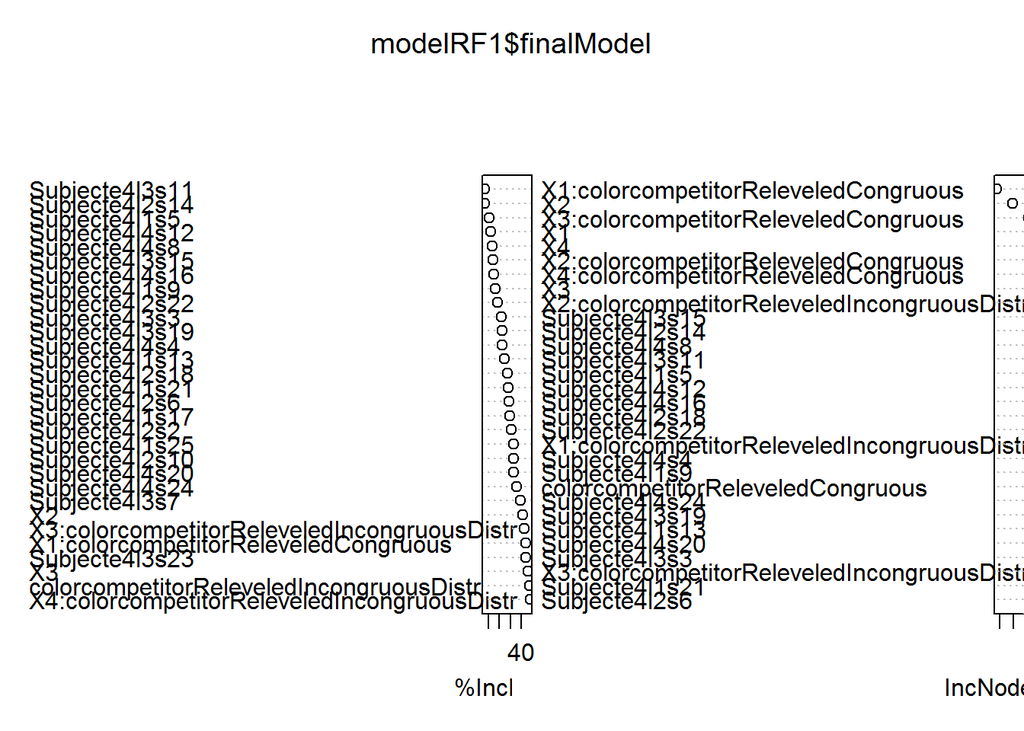

```r
varImpPlot(modelRF1$finalModel)
```

```r
#Examine RMSE
RMSERandomForest<-sqrt(mean((model$Prob-modelRF1$finalModel$predicted)^2))

#attach the predicted values to the dataset for later graphing purposes
model$RF1<-modelRF1$finalModel$predicted
```

The linear component seems to be very important. A simpler model is implemented below:

```r
set.seed(123)
modelRF2<-train(Prob~(X1)*colorcompetitorReleveled+Subject, method="rf", data=model,
                trControl = trainControl(method = "cv", number = 5),
                 ntree = 200, importance = TRUE)
#Examine Model Ouput
modelRF2
```

```
## Random Forest
##
## 7650 samples
##   17 predictor
##
## No pre-processing
## Resampling: Cross-Validated (5 fold)
##
## Summary of sample sizes: 6121, 6120, 6120, 6120, 6119
##
## Resampling results across tuning parameters:
##
##   mtry  RMSE        Rsquared   RMSE SD      Rsquared SD
##    2    0.20305956  0.6908989  0.006706407  0.021022580
##   15    0.05667387  0.9651040  0.002527070  0.003326990
##   29    0.05257362  0.9692957  0.002091014  0.002769722
##
## RMSE was used to select the optimal model using  the smallest value.
## The final value used for the model was mtry = 29.
```

```r
#Examine the best model
modelRF2$finalModel
```

```
##
## Call:
##  randomForest(x = x, y = y, ntree = 200, mtry = param$mtry, importance = TRUE)
##                Type of random forest: regression
##                      Number of trees: 200
## No. of variables tried at each split: 29
##
##           Mean of squared residuals: 0.002165086
##                     % Var explained: 97.56
```

```r
#Examine Variable Importance
modelRF2$finalModel$importance
```

```
##                                                  %IncMSE IncNodePurity
## X1                                          0.0801282067    183.801008
## colorcompetitorReleveledCongruous           0.0139333104      8.733284
## colorcompetitorReleveledIncongruousDistr    0.0039375594     11.016901
## Subjecte4l1s13                              0.0025546883      6.856013
## Subjecte4l1s17                              0.0013395280      4.392488
## Subjecte4l1s21                              0.0015287910      4.520964
## Subjecte4l1s25                              0.0012079539      3.504052
## Subjecte4l1s5                               0.0062790946     15.034648
## Subjecte4l1s9                               0.0028012283      7.908874
## Subjecte4l2s10                              0.0014692872      4.029139
## Subjecte4l2s14                              0.0071607671     17.525843
## Subjecte4l2s18                              0.0028322770      8.309811
## Subjecte4l2s2                               0.0013281179      4.178110
## Subjecte4l2s22                              0.0031469140      8.173642
## Subjecte4l2s6                               0.0013896856      4.380827
## Subjecte4l3s11                              0.0057766664     14.869320
## Subjecte4l3s15                              0.0069880780     17.061590
## Subjecte4l3s19                              0.0022874504      7.024948
## Subjecte4l3s23                              0.0006265100      2.701217
## Subjecte4l3s3                               0.0020146735      5.810590
## Subjecte4l3s7                               0.0007965915      2.043318
## Subjecte4l4s12                              0.0048110433     12.512861
## Subjecte4l4s16                              0.0038570193      9.184963
## Subjecte4l4s20                              0.0014617871      5.052021
## Subjecte4l4s24                              0.0016697162      5.863635
## Subjecte4l4s4                               0.0023595210      7.248833
## Subjecte4l4s8                               0.0045430649     14.568413
## X1:colorcompetitorReleveledCongruous        0.0977211773    261.409984
## X1:colorcompetitorReleveledIncongruousDistr 0.0047570607     17.086571
```

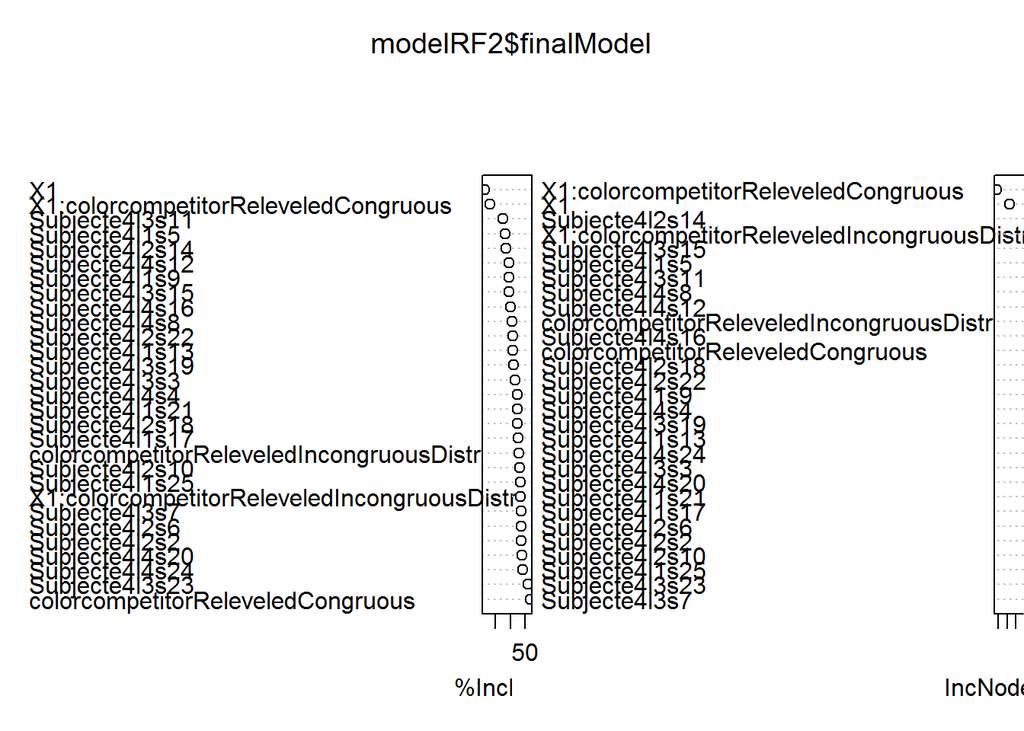

```r
varImpPlot(modelRF2$finalModel)
```

```r
#Examine RMSE
sqrt(mean((model$Prob-modelRF2$finalModel$predicted)^2))
```

```
## [1] 0.04653049
```

```r
#attach the predicted values to the dataset
model$RF2<-modelRF2$finalModel$predicted
```

Simpler model again performs better

### *Competitor (Congruent) vs. Competitor (Incongruent COmp) vs. Competitor (Incongruent Distr.)*

The required subset for the `2nd` analysis is created. This analysis compares competitors for each condition

```r
#find proportion for each interest area for each subject
CleanDataProb2<-CleanData %>% group_by(Subject,colorcompetitor,IA_LABEL,trialtype,time) %>%
    summarise(Prob=mean(value))
CleanDataProb2$time<-as.numeric(as.character(CleanDataProb2$time))

modelData<-CleanDataProb2 %>%
    filter(trialtype=="Experimental", IA_LABEL=="COMPET_IA ", colorcompetitor!="Practice", time>=2000+675 & time <=5200)

modelData$colorcompetitor<-as.factor(as.character(modelData$colorcompetitor))

modelData$colorcompetitorReleveled <- relevel(modelData$colorcompetitor, "IncongruousDistr")

#Generate time polynomials up to quadratic poly.
t25 <- data.frame(poly(unique(modelData$time),4))
t25$time <- seq(2675, 5200, by=25)

#add polynomials to data frame
modelData <- merge(modelData , t25, by="time")
head(modelData)
```

```
##   time Subject  colorcompetitor   IA_LABEL    trialtype       Prob
## 1 2675  e4l1s1        Congruous COMPET_IA  Experimental 0.00000000
## 2 2675 e4l2s14  IncongruousComp COMPET_IA  Experimental 0.09090909
## 3 2675 e4l3s23 IncongruousDistr COMPET_IA  Experimental 0.08333333
## 4 2675  e4l3s7        Congruous COMPET_IA  Experimental 0.09090909
## 5 2675 e4l1s13  IncongruousComp COMPET_IA  Experimental 0.00000000
## 6 2675  e4l3s7 IncongruousDistr COMPET_IA  Experimental 0.16666667
##   colorcompetitorReleveled         X1        X2         X3        X4
## 1                Congruous -0.1698254 0.2149861 -0.2470002 0.2692958
## 2          IncongruousComp -0.1698254 0.2149861 -0.2470002 0.2692958
## 3         IncongruousDistr -0.1698254 0.2149861 -0.2470002 0.2692958
## 4                Congruous -0.1698254 0.2149861 -0.2470002 0.2692958
## 5          IncongruousComp -0.1698254 0.2149861 -0.2470002 0.2692958
## 6         IncongruousDistr -0.1698254 0.2149861 -0.2470002 0.2692958
```

```r
str(modelData)
```

```
## 'data.frame':    7650 obs. of  11 variables:
##  $ time                    : num  2675 2675 2675 2675 2675 ...
##  $ Subject                 : Factor w/ 25 levels "e4l1s1","e4l1s13",..: 1 9 17 19 2 19 3 11 3 12 ...
##  $ colorcompetitor         : Factor w/ 3 levels "Congruous","IncongruousComp",..: 1 2 3 1 2 3 1 2 3 3 ...
##  $ IA_LABEL                : Factor w/ 4 levels "COMPET_IA ","TARGET_IA ",..: 1 1 1 1 1 1 1 1 1 1 ...
##  $ trialtype               : Factor w/ 4 levels "Experimental",..: 1 1 1 1 1 1 1 1 1 1 ...
##  $ Prob                    : num  0 0.0909 0.0833 0.0909 0 ...
##  $ colorcompetitorReleveled: Factor w/ 3 levels "IncongruousDistr",..: 2 3 1 2 3 1 2 3 1 1 ...
##  $ X1                      : num  -0.17 -0.17 -0.17 -0.17 -0.17 ...
##  $ X2                      : num  0.215 0.215 0.215 0.215 0.215 ...
##  $ X3                      : num  -0.247 -0.247 -0.247 -0.247 -0.247 ...
##  $ X4                      : num  0.269 0.269 0.269 0.269 0.269 ...
```

### *Run Growth Curve Analyses*

The following models are run, with increasing complexity: Model 1: A base model with no polynomials and only with the fixed effect IA_LABEL and random effect of subject intercept and nested condition with subject intercept.

Model 2: Base model with the addition of the linear polynomial for the fixed and random effect structure; Model Fails to converge

Model 3. Model above+random slope of X1 is removed from subjct:condition; fails to converge

Model 4. Model 2 random slope is removed from subject. fails to converge

Model 5. Model 2 wihtout random slopes; no issues

```r
registerDoParallel(3)
#base model; Model1
Model1<-lmer(Prob ~ colorcompetitorReleveled +
                 (1| Subject) +
                 (1| Subject:colorcompetitorReleveled),
               data=modelData, REML=T)
summary(Model1)
```

```
## Linear mixed model fit by REML t-tests use Satterthwaite approximations
##   to degrees of freedom [lmerMod]
## Formula:
## Prob ~ colorcompetitorReleveled + (1 | Subject) + (1 | Subject:colorcompetitorReleveled)
##    Data: modelData
##
## REML criterion at convergence: -4184
##
## Scaled residuals:
##     Min      1Q  Median      3Q     Max
## -1.7202 -0.4184 -0.1097  0.1810  4.1076
##
## Random effects:
##  Groups                           Name        Variance  Std.Dev.
##  Subject:colorcompetitorReleveled (Intercept) 1.142e-03 3.380e-02
##  Subject                          (Intercept) 3.711e-16 1.926e-08
##  Residual                                     3.330e-02 1.825e-01
## Number of obs: 7650, groups:
## Subject:colorcompetitorReleveled, 75; Subject, 25
##
## Fixed effects:
##                                          Estimate Std. Error        df
## (Intercept)                              0.077662   0.007665 72.000000
## colorcompetitorReleveledCongruous       -0.056233   0.010840 72.000000
## colorcompetitorReleveledIncongruousComp  0.151093   0.010840 72.000000
##                                         t value Pr(>|t|)
## (Intercept)                              10.132 1.78e-15 ***
## colorcompetitorReleveledCongruous        -5.187 1.89e-06 ***
## colorcompetitorReleveledIncongruousComp  13.938  < 2e-16 ***
## ---
## Signif. codes:  0 '***' 0.001 '**' 0.01 '*' 0.05 '.' 0.1 ' ' 1
##
## Correlation of Fixed Effects:
##             (Intr) clrcRC
## clrcmpttrRC -0.707
## clrcmpttRIC -0.707  0.500
```

```r
#linear; model 2
Model2<-lmer(Prob ~ colorcompetitorReleveled*X1 +
                 (1+X1| Subject) +
                 (1+X1| Subject:colorcompetitorReleveled),
               data=modelData, REML=T)
summary(Model2) #model fails to converge
```

```
## Linear mixed model fit by REML t-tests use Satterthwaite approximations
##   to degrees of freedom [lmerMod]
## Formula: Prob ~ colorcompetitorReleveled * X1 + (1 + X1 | Subject) + (1 +
##     X1 | Subject:colorcompetitorReleveled)
##    Data: modelData
##
## REML criterion at convergence: -10051
##
## Scaled residuals:
##     Min      1Q  Median      3Q     Max
## -6.6683 -0.3841 -0.0678  0.2998  4.2735
##
## Random effects:
##  Groups                           Name        Variance Std.Dev. Corr
##  Subject:colorcompetitorReleveled (Intercept) 0.001321 0.03634
##                                   X1          0.089140 0.29856  -0.73
##  Subject                          (Intercept) 0.000000 0.00000
##                                   X1          0.002869 0.05357   NaN
##  Residual                                     0.015111 0.12293
## Number of obs: 7650, groups:
## Subject:colorcompetitorReleveled, 75; Subject, 25
##
## Fixed effects:
##                                             Estimate Std. Error        df
## (Intercept)                                 0.077662   0.007665 72.000000
## colorcompetitorReleveledCongruous          -0.056233   0.010840 72.000000
## colorcompetitorReleveledIncongruousComp     0.151093   0.010840 72.000000
## X1                                         -0.437217   0.065459 71.940000
## colorcompetitorReleveledCongruous:X1        0.215812   0.091324 57.170000
## colorcompetitorReleveledIncongruousComp:X1 -1.800484   0.091324 57.170000
##                                            t value Pr(>|t|)
## (Intercept)                                 10.132 1.78e-15 ***
## colorcompetitorReleveledCongruous           -5.187 1.89e-06 ***
## colorcompetitorReleveledIncongruousComp     13.938  < 2e-16 ***
## X1                                          -6.679 4.30e-09 ***
## colorcompetitorReleveledCongruous:X1         2.363   0.0215 *
## colorcompetitorReleveledIncongruousComp:X1 -19.715  < 2e-16 ***
## ---
## Signif. codes:  0 '***' 0.001 '**' 0.01 '*' 0.05 '.' 0.1 ' ' 1
##
## Correlation of Fixed Effects:
##             (Intr) clrcRC clrRIC X1     cRC:X1
## clrcmpttrRC -0.707
## clrcmpttRIC -0.707  0.500
## X1          -0.632  0.447  0.447
## clrcmpRC:X1  0.453 -0.640 -0.320 -0.698
## clrcmRIC:X1  0.453 -0.320 -0.640 -0.698  0.500
## convergence code: 0
## Model failed to converge with max|grad| = 0.0177776 (tol = 0.002, component 1)
```

```r
#linea+quadratic; model 3
Model3<-lmer(Prob ~ colorcompetitorReleveled*(X1) +
                 (1+X1| Subject) +
                 (1| Subject:colorcompetitorReleveled),
               data=modelData, REML=T)
#model 3 fails to converge
#Model 4
Model4<-lmer(Prob ~ colorcompetitorReleveled*(X1) +
                 (1| Subject) +
                 (1+X1| Subject:colorcompetitorReleveled),
               data=modelData, REML=T)
#model 4 fails to converge
#Model 5
Model5<-lmer(Prob ~ colorcompetitorReleveled*(X1) +
                 (1| Subject) +
                 (1| Subject:colorcompetitorReleveled),
               data=modelData, REML=T)
#Model 5 converges
#compare the models based on ANOVA test
anova(Model1,Model2,Model3,Model4,Model5)
```

```
## refitting model(s) with ML (instead of REML)
```

```
## Data: modelData
## Models:
## object: Prob ~ colorcompetitorReleveled + (1 | Subject) + (1 | Subject:colorcompetitorReleveled)
## ..4: Prob ~ colorcompetitorReleveled * (X1) + (1 | Subject) + (1 |
## ..4:     Subject:colorcompetitorReleveled)
## ..2: Prob ~ colorcompetitorReleveled * (X1) + (1 + X1 | Subject) +
## ..2:     (1 | Subject:colorcompetitorReleveled)
## ..3: Prob ~ colorcompetitorReleveled * (X1) + (1 | Subject) + (1 +
## ..3:     X1 | Subject:colorcompetitorReleveled)
## ..1: Prob ~ colorcompetitorReleveled * X1 + (1 + X1 | Subject) + (1 +
## ..1:     X1 | Subject:colorcompetitorReleveled)
##        Df      AIC     BIC logLik deviance    Chisq Chi Df Pr(>Chisq)
## object  6  -4195.8 -4154.2 2103.9  -4207.8
## ..4     9  -9751.3 -9688.8 4884.7  -9769.3 5561.501      3     <2e-16 ***
## ..2    11  -9837.9 -9761.5 4929.9  -9859.9   90.553      2     <2e-16 ***
## ..3    11 -10065.1 -9988.7 5043.6 -10087.1  227.249      0     <2e-16 ***
## ..1    13 -10061.3 -9971.0 5043.6 -10087.3    0.145      2     0.9301
## ---
## Signif. codes:  0 '***' 0.001 '**' 0.01 '*' 0.05 '.' 0.1 ' ' 1
```

```r
#compare the models based on R^2 based on a paper from Xu (http://onlinelibrary.wiley.com/doi/10.1002/sim.1572/abstract)
1-var(residuals(Model1))/(var(model.response(model.frame(Model1))))
```

```
## [1] 0.2141601
```

```r
1-var(residuals(Model2))/(var(model.response(model.frame(Model2))))
```

```
## [1] 0.6462932
```

```r
1-var(residuals(Model3))/(var(model.response(model.frame(Model3))))
```

```
## [1] 0.6311273
```

```r
1-var(residuals(Model4))/(var(model.response(model.frame(Model4))))
```

```
## [1] 0.646297
```

```r
1-var(residuals(Model5))/(var(model.response(model.frame(Model5))))
```

```
## [1] 0.6232939
```

```r
#find the summary for model 5
summary(Model5)
```

```
## Linear mixed model fit by REML t-tests use Satterthwaite approximations
##   to degrees of freedom [lmerMod]
## Formula: Prob ~ colorcompetitorReleveled * (X1) + (1 | Subject) + (1 |
##     Subject:colorcompetitorReleveled)
##    Data: modelData
##
## REML criterion at convergence: -9729
##
## Scaled residuals:
##     Min      1Q  Median      3Q     Max
## -5.5192 -0.3876 -0.0855  0.2915  3.9480
##
## Random effects:
##  Groups                           Name        Variance  Std.Dev.
##  Subject:colorcompetitorReleveled (Intercept) 1.312e-03 3.622e-02
##  Subject                          (Intercept) 1.015e-16 1.007e-08
##  Residual                                     1.599e-02 1.264e-01
## Number of obs: 7650, groups:
## Subject:colorcompetitorReleveled, 75; Subject, 25
##
## Fixed effects:
##                                              Estimate Std. Error
## (Intercept)                                 7.766e-02  7.665e-03
## colorcompetitorReleveledCongruous          -5.623e-02  1.084e-02
## colorcompetitorReleveledIncongruousComp     1.511e-01  1.084e-02
## X1                                         -4.372e-01  2.529e-02
## colorcompetitorReleveledCongruous:X1        2.158e-01  3.576e-02
## colorcompetitorReleveledIncongruousComp:X1 -1.800e+00  3.576e-02
##                                                    df t value Pr(>|t|)
## (Intercept)                                 7.200e+01  10.132 1.78e-15 ***
## colorcompetitorReleveledCongruous           7.200e+01  -5.187 1.89e-06 ***
## colorcompetitorReleveledIncongruousComp     7.200e+01  13.938  < 2e-16 ***
## X1                                          7.572e+03 -17.290  < 2e-16 ***
## colorcompetitorReleveledCongruous:X1        7.572e+03   6.035 1.67e-09 ***
## colorcompetitorReleveledIncongruousComp:X1  7.572e+03 -50.348  < 2e-16 ***
## ---
## Signif. codes:  0 '***' 0.001 '**' 0.01 '*' 0.05 '.' 0.1 ' ' 1
##
## Correlation of Fixed Effects:
##             (Intr) clrcRC clrRIC X1     cRC:X1
## clrcmpttrRC -0.707
## clrcmpttRIC -0.707  0.500
## X1           0.000  0.000  0.000
## clrcmpRC:X1  0.000  0.000  0.000 -0.707
## clrcmRIC:X1  0.000  0.000  0.000 -0.707  0.500
```

```r
#find the RMSE
sqrt(mean((modelData$Prob-fitted(Model5))^2))
```

```
## [1] 0.1258523
```

```r
#attach the fitted values to the dataset modelData, so that they can be used later for graphing purposes
modelData$Model1Fitted<-fitted(Model1)
modelData$Model2Fitted<-fitted(Model2)
modelData$Model3Fitted<-fitted(Model3)
modelData$Model4Fitted<-fitted(Model4)
modelData$Model5Fitted<-fitted(Model5)
```

The first models examines the inclusion of all 4 polynomials interacting with the IA_LABEL and the inclusion of Subject ID

```r
set.seed(123)
modelRF1<-train(Prob~(X1+X2+X3+X4)*colorcompetitorReleveled+Subject, method="rf", data=modelData,
                trControl = trainControl(method = "cv", number = 5),
                 ntree = 200, importance = TRUE)
#Examine Model Ouput
modelRF1
```

```
## Random Forest
##
## 7650 samples
##   15 predictor
##
## No pre-processing
## Resampling: Cross-Validated (5 fold)
##
## Summary of sample sizes: 6120, 6119, 6120, 6121, 6120
##
## Resampling results across tuning parameters:
##
##   mtry  RMSE        Rsquared   RMSE SD       Rsquared SD
##    2    0.09254486  0.8416363  0.0016963181  0.019085543
##   20    0.04571145  0.9514472  0.0009538382  0.001988240
##   38    0.04497212  0.9530319  0.0008670270  0.002105391
##
## RMSE was used to select the optimal model using  the smallest value.
## The final value used for the model was mtry = 38.
```

```r
#Examine the best model
modelRF1$finalModel
```

```
##
## Call:
##  randomForest(x = x, y = y, ntree = 200, mtry = param$mtry, importance = TRUE)
##                Type of random forest: regression
##                      Number of trees: 200
## No. of variables tried at each split: 38
##
##           Mean of squared residuals: 0.001557372
##                     % Var explained: 96.3
```

```r
#Examine Variable Importance
modelRF1$finalModel$importance
```

```
##                                                 %IncMSE IncNodePurity
## X1                                         0.0083927725    14.9384545
## X2                                         0.0034652975     6.5988643
## X3                                         0.0024102864     5.4295154
## X4                                         0.0032047227    11.8371507
## colorcompetitorReleveledCongruous          0.0042426664     6.3097814
## colorcompetitorReleveledIncongruousComp    0.0002522859     0.6662614
## Subjecte4l1s13                             0.0009942943     2.1846558
## Subjecte4l1s17                             0.0004176443     1.3313621
## Subjecte4l1s21                             0.0003596990     1.9421383
## Subjecte4l1s25                             0.0004936111     1.6489582
## Subjecte4l1s5                              0.0006181357     1.7991628
## Subjecte4l1s9                              0.0004120029     1.3451917
## Subjecte4l2s10                             0.0010707744     2.5517384
## Subjecte4l2s14                             0.0005187863     1.3203589
## Subjecte4l2s18                             0.0002455681     1.0669196
## Subjecte4l2s2                              0.0008031706     1.6584438
## Subjecte4l2s22                             0.0011854079     2.6619663
## Subjecte4l2s6                              0.0003558383     0.9030227
## Subjecte4l3s11                             0.0005988815     1.9588483
## Subjecte4l3s15                             0.0016021844     3.3622586
## Subjecte4l3s19                             0.0012268378     2.9834088
## Subjecte4l3s23                             0.0003746238     1.1982979
## Subjecte4l3s3                              0.0005021173     1.4035883
## Subjecte4l3s7                              0.0004062653     1.1870345
## Subjecte4l4s12                             0.0004798688     1.9734336
## Subjecte4l4s16                             0.0017596222     3.7372513
## Subjecte4l4s20                             0.0002395045     0.9705963
## Subjecte4l4s24                             0.0003436385     1.2198921
## Subjecte4l4s4                              0.0005502252     1.3439520
## Subjecte4l4s8                              0.0009355210     2.2601557
## X1:colorcompetitorReleveledCongruous       0.0003122595     0.5557798
## X1:colorcompetitorReleveledIncongruousComp 0.0506239810   206.9763194
## X2:colorcompetitorReleveledCongruous       0.0002234186     0.3771194
## X2:colorcompetitorReleveledIncongruousComp 0.0019479407     4.1772394
## X3:colorcompetitorReleveledCongruous       0.0008577836     1.5519185
## X3:colorcompetitorReleveledIncongruousComp 0.0008104815     2.4913357
## X4:colorcompetitorReleveledCongruous       0.0001432077     0.2926659
## X4:colorcompetitorReleveledIncongruousComp 0.0027321843    12.2723900
```

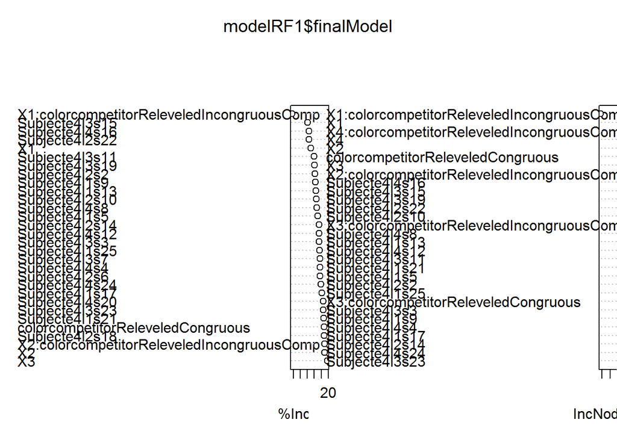

```r
varImpPlot(modelRF1$finalModel)
```

```r
#Examine RMSE
RMSERandomForest<-sqrt(mean((model$Prob-modelRF1$finalModel$predicted)^2))
#attach predicted values
modelData$RF1<-modelRF1$finalModel$predicted
```

The third poly and some of the interactions between poly and conditions seem to be redundant

```r
set.seed(123)
modelRF2<-train(Prob~(X1)*colorcompetitorReleveled+Subject, method="rf", data=modelData,
                trControl = trainControl(method = "cv", number = 5),
                 ntree = 200, importance = TRUE)
#Examine Model Ouput
modelRF2
```

```
## Random Forest
##
## 7650 samples
##   16 predictor
##
## No pre-processing
## Resampling: Cross-Validated (5 fold)
##
## Summary of sample sizes: 6120, 6119, 6120, 6121, 6120
##
## Resampling results across tuning parameters:
##
##   mtry  RMSE        Rsquared   RMSE SD       Rsquared SD
##    2    0.11126232  0.7912915  0.0019171581  0.017880615
##   15    0.04443560  0.9543829  0.0014033646  0.002336630
##   29    0.04300412  0.9571797  0.0009044819  0.001470556
##
## RMSE was used to select the optimal model using  the smallest value.
## The final value used for the model was mtry = 29.
```

```r
#Examine the best model
modelRF2$finalModel
```

```
##
## Call:
##  randomForest(x = x, y = y, ntree = 200, mtry = param$mtry, importance = TRUE)
##                Type of random forest: regression
##                      Number of trees: 200
## No. of variables tried at each split: 29
##
##           Mean of squared residuals: 0.001438292
##                     % Var explained: 96.58
```

```r
#Examine Variable Importance
modelRF2$finalModel$importance
```

```
##                                                 %IncMSE IncNodePurity
## X1                                         0.0172817968    38.7577478
## colorcompetitorReleveledCongruous          0.0055285456     7.9321510
## colorcompetitorReleveledIncongruousComp    0.0012065785     2.9346871
## Subjecte4l1s13                             0.0010146285     2.3691080
## Subjecte4l1s17                             0.0004837893     1.2742876
## Subjecte4l1s21                             0.0004179615     1.9722159
## Subjecte4l1s25                             0.0005331092     1.7420885
## Subjecte4l1s5                              0.0006135905     1.6700226
## Subjecte4l1s9                              0.0004396932     1.4013559
## Subjecte4l2s10                             0.0010831461     2.4138428
## Subjecte4l2s14                             0.0005596318     1.3305742
## Subjecte4l2s18                             0.0002823480     1.1723398
## Subjecte4l2s2                              0.0007970237     1.5959708
## Subjecte4l2s22                             0.0012213458     2.7558417
## Subjecte4l2s6                              0.0003556631     0.8573953
## Subjecte4l3s11                             0.0006297212     2.0260172
## Subjecte4l3s15                             0.0016980401     2.8547681
## Subjecte4l3s19                             0.0013374070     2.9226821
## Subjecte4l3s23                             0.0003726024     1.1626293
## Subjecte4l3s3                              0.0005411312     1.4581355
## Subjecte4l3s7                              0.0004459426     1.2705590
## Subjecte4l4s12                             0.0005003465     1.9661123
## Subjecte4l4s16                             0.0018545511     3.7631979
## Subjecte4l4s20                             0.0002562403     0.9175298
## Subjecte4l4s24                             0.0003597846     1.2159629
## Subjecte4l4s4                              0.0006036757     1.3644604
## Subjecte4l4s8                              0.0008729669     2.1160080
## X1:colorcompetitorReleveledCongruous       0.0005547106     1.3307959
## X1:colorcompetitorReleveledIncongruousComp 0.0554496948   224.9579720
```

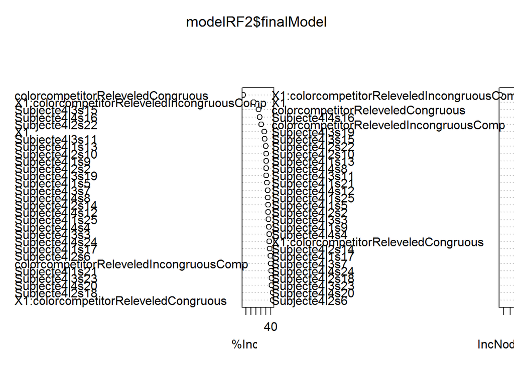

```r
varImpPlot(modelRF2$finalModel)
```

```r
#Examine RMSE
sqrt(mean((modelData$Prob-modelRF2$finalModel$predicted)^2))
```

```
## [1] 0.03792483
```

```r
#attached predicted values
modelData$RF2<-modelRF2$finalModel$predicted
```

The cross-validated random forest model fewer components performs a bit better than the one that has more components.

## **Graphs**

Each model used above will be graphed by overlaying it on the real data. First, the plots for the first comparison will be created. For this, I use the model dataset. I put the data in long only format.

```r
ModelLong<- model %>% gather(Model,Predictions,12:19)
#rename the models so that they are more clear
levels(ModelLong$Model) <- list(`Model 1 Intercept`="Model1Fitted", `Model 2 Linear`="Model2Fitted", `Model 3 Quadratic`="Model3Fitted", `Model 4 Cubic (not converged)`="Model4Fitted", `Model 5 Cubic`="Model5Fitted", `Model 6 Cubic (not converged)`="Model6Fitted", `Random Forest Complex`="RF1",`Random Forest Simple`="RF2")

#rename some of the colums
colnames(ModelLong)[3]<-"Congruence"
ModelLong[,3]<-factor(ModelLong[,3])
#compress the data(find the average over subjects)
ForGraph1<-ModelLong %>% group_by(Congruence,time, Model) %>%
    summarise(`Fixation Probability`=mean(Prob),Predicted=mean(Predictions))
```

The code chunk below will plot and save the graph

```r
#color palette for color-blind
cbPalette <- c("#999999", "#E69F00", "#56B4E9", "#009E73", "#F0E442", "#0072B2", "#D55E00", "#CC79A7")
#create plot1 for Experiment 1, which goes in the publication
png(filename="plot4Experiment4.png",width=900,height=524)
ggplot(ForGraph1, aes(x=time, y=`Fixation Probability`, shape=Congruence, color=Congruence)) +
    geom_point(size=3) + geom_line(aes(y=Predicted), size=1)+facet_wrap(~Model, nrow=2, ncol=4)+
    scale_fill_manual(values=cbPalette)+scale_colour_manual(values=cbPalette)+
    ggtitle("Fixation Proportion for Models\n examining Targets by Congruence")+
    theme_bw()+
    scale_x_continuous(name="time 200ms from display onset(ms)")+
    theme(legend.text = element_text(size = 12))+
    theme(legend.title = element_text(size=12, face="bold"))+
    theme(axis.title.x = element_text(face="bold", size=15), axis.text.x  = element_text(size=12))+
    theme(axis.title.y = element_text(face="bold", size=15), axis.text.y  = element_text(size=12))+
    theme(strip.text.x = element_text(size=12, face="bold"))+
    theme(plot.title = element_text(lineheight=.8, face="bold", size=14))+
    scale_y_continuous(limits = c(0, 1))
dev.off()
```

```r
ModelLong<- modelData %>% gather(Model,Predictions,12:18)
#rename the models so that they are more clear
levels(ModelLong$Model) <- list(`Model 1 Intercept`="Model1Fitted", `Model 2 Linear (not converged`="Model2Fitted", `Model 3 Linear (not converged)`="Model3Fitted", `Model 4 Linear (not converged)`="Model4Fitted", `Model 5 Linear`="Model5Fitted",`Random Forest Complex`="RF1",`Random Forest Simple`="RF2")

#rename some of the colums
colnames(ModelLong)[3]<-"Congruence"
ModelLong[,3]<-factor(ModelLong[,3])
#compress the data(find the average over subjects)
ForGraph2<-ModelLong %>% group_by(Congruence,time, Model) %>%
    summarise(`Fixation Probability`=mean(Prob),Predicted=mean(Predictions))
```

The code chunk below will plot and save the graph

```r
#color palette for color-blind
cbPalette <- c("#999999", "#E69F00", "#56B4E9", "#009E73", "#F0E442", "#0072B2", "#D55E00", "#CC79A7")
#create plot1 for Experiment 1, which goes in the publication
png(filename="plot5Experiment4.png",width=900,height=524)
ggplot(ForGraph2, aes(x=time, y=`Fixation Probability`, shape=Congruence, color=Congruence)) +
    geom_point(size=3) + geom_line(aes(y=Predicted), size=1)+facet_wrap(~Model, nrow=2, ncol=4)+
    scale_fill_manual(values=cbPalette)+scale_colour_manual(values=cbPalette)+
    ggtitle("Fixation Proportion for Models\n examining Target vs. Competitor")+
    theme_bw()+
    scale_x_continuous(name="time 200ms from display onset(ms)")+
    theme(legend.text = element_text(size = 12))+
    theme(legend.title = element_text(size=12, face="bold"))+
    theme(axis.title.x = element_text(face="bold", size=15), axis.text.x  = element_text(size=12))+
    theme(axis.title.y = element_text(face="bold", size=15), axis.text.y  = element_text(size=12))+
    theme(strip.text.x = element_text(size=12, face="bold"))+
    theme(plot.title = element_text(lineheight=.8, face="bold", size=14))+
    scale_y_continuous(limits = c(0, 1))
dev.off()
```